# Portfolio 5 Part 1: MCPs

Justine Lang

2024-01-30

```r
knitr::opts_chunk$set(echo = TRUE, warning = FALSE, message = FALSE, results = FALSE)

### Our usual friends
library(tidyverse)
library(here)
library(janitor)

### The main package we're working with
library(adehabitatHR)

### For working with SpatialPointsDataFrames
library(sp)

### To help with display
library(scales)
library(ggmap) ### ggmap is outdated; can use leaflet instead
```

For simplicity’s (and R’s) sake, we’re going to filter our telemetry data to 6 elk from the National Elk Refuge.

```r
### Read the csv
elk <- read_csv(here("Habitat_Portfolio","elk_collar.csv"))

### Convert the elk ID column to character to prevent R from getting confused
elk <- elk %>%
  mutate_at("id", as.character)

### To start, let's filter to 6 elk from the National Elk Refuge
elk_ner <- elk %>%
  filter(feedground == "National_Elk_Refuge") %>%  #select a feedground of interest
  filter(id %in% c("631", "632", "633", "634", "635", "636")) #select id of elk of interest
```

Creating a SpatialPointsDataFrame (from the `sp` package) is necessary for creating the home ranges in `adehabitatHR`. To accomplish this, define the coordinates and set the coordinate reference system.

```r
### SpatialPointsDataFrame objects don't like missing values, so it helps to remove NA's
elk_ner <- elk_ner[!is.na(elk_ner$x) & !is.na(elk_ner$y),]

### Only need three columns (id, x, and y coordinates)
elk.sp <- elk_ner[, c("id", "x", "y")]

### Define coordinates to create a SpatialPointsDataFrame
coordinates(elk.sp) <- c("x", "y")

### Set the coordinate reference system (CRS)
### The data are UTM points in WGS84 from zone 12N
proj4string(elk.sp) <- CRS("+proj=utm +zone=12 +datum=WGS84 +units=m +no_defs")
```

Use the `mcp` function to calculate the Minimum Convex Polygons. Set the percentage of relocation points to be used to construct the home ranges. Examining the output will provide the home range area.

```r
### Calculate MCPs for each elk
elk.mcp <- mcp(elk.sp, percent = 100) #change the percentage & see how the polygon shapes & area change below

### Examine output
elk.mcp
```

Then we can plot our home range polygons.

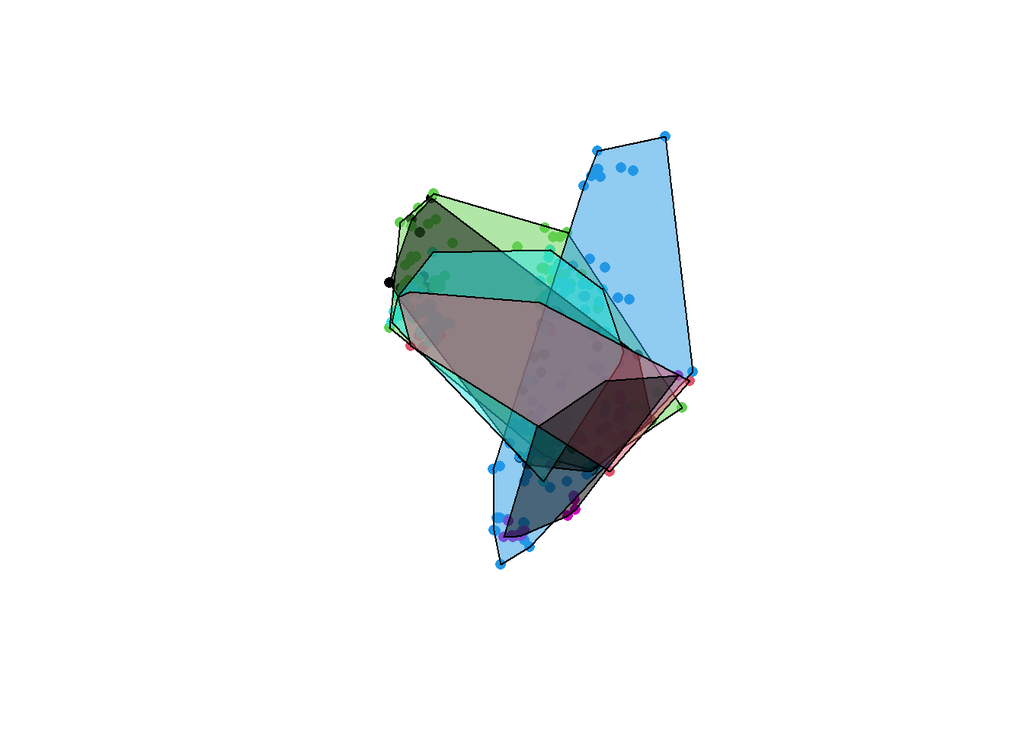

```r
### Plot
### library(scales) # Helps make polygons partly transparent using the alpha argument below
plot(elk.sp, col = as.factor(elk.sp@data$id), pch = 16)
plot(elk.mcp, col = alpha(1:5, 0.5), add = TRUE)
```

In this example, we use 100% of relocations to create the elk home ranges, but are all of these areas normally used by individuals? When defining home range, it is important to consider the biology of the species. With an animal that does not move much, such as certain reptiles, it may make sense to include all relocation points. With more mobile birds and mammals, however, this may not be the best approach.

The graphs below, created with the `mcp.area` function, show how the elk home range changes from including 50% to 100% of points. A more linear increase generally indicates a less stable home range size.

```r
### Calculate the MCP by including 50 to 100 percent of points
hrs <- mcp.area(elk.sp, percent = seq(50, 100, by = 5))
```

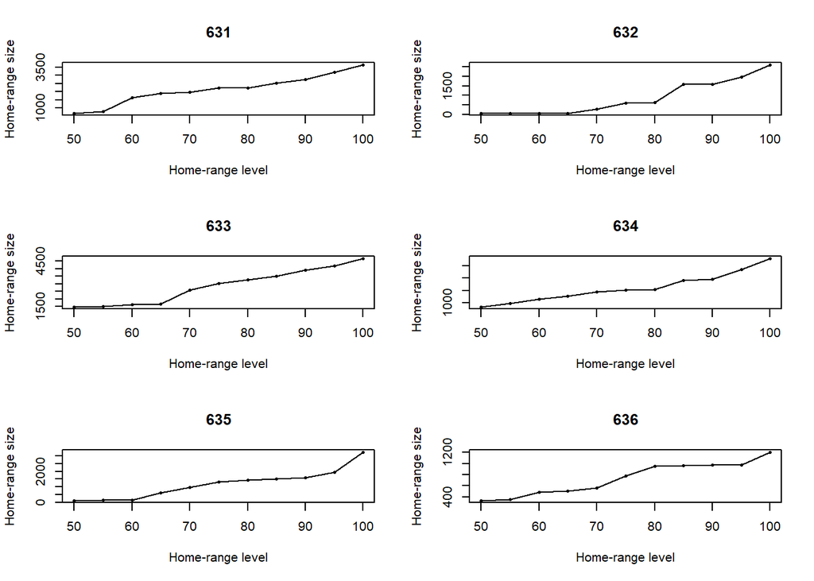

```r
### Use "Plot Zoom" in the console or "Show in New Window" for inline output to see the full graphs
### R doesn't like to display the graphs for more than a few animals/groups at a time; it will give you an error if you try to display too many
```

```r
hrs ### examine dataframe of home-range size
```

You can also plot the MCPs over a basemap. Here we use the `ggmap` package. There are instructions below for generating your own API key to create a basemap.

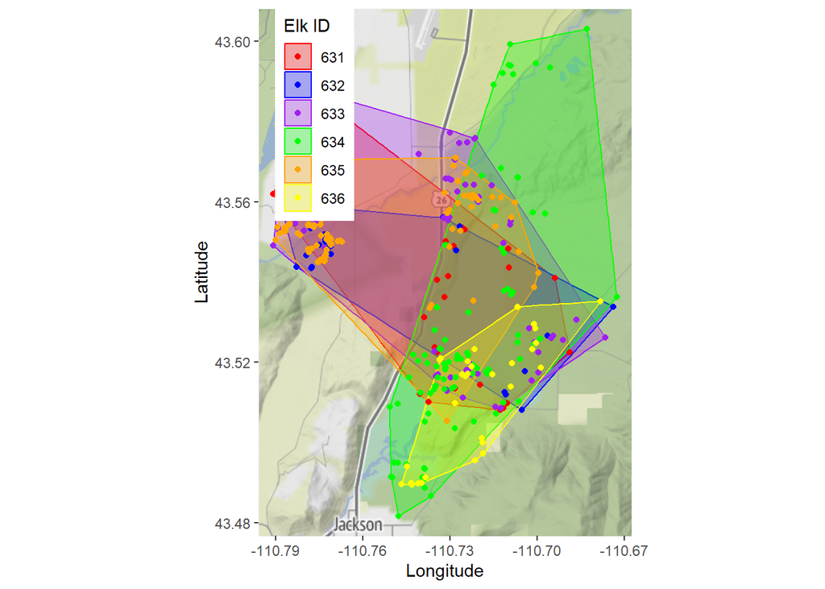

```r
# Transform the point and MCP objects.
elk.spgeo <- spTransform(elk.sp, CRS("+proj=longlat"))
elk.mcpgeo <- spTransform(elk.mcp, CRS("+proj=longlat"))

### To use the stadiamaps basemaps, you will need to generate your own API key
### You can generate your own for free here: https://client.stadiamaps.com/signup/

register_stadiamaps(key = "abd38f6a-07a9-43fb-99fa-9288b2fdb209")

mybasemap <- get_stadiamap(bbox = c(left = min(elk.spgeo@coords[,1])-0.005,
                                    bottom = min(elk.spgeo@coords[,2])-0.005,
                                    right = max(elk.spgeo@coords[,1])+0.005,
                                    top = max(elk.spgeo@coords[,2])+0.005),
                           zoom = 12)

# Turn the spatial data frame of points into just a dataframe for plotting in ggmap
elk.geo <- data.frame(elk.spgeo@coords,
                          id = elk.spgeo@data$id )

mymap.hr <- ggmap(mybasemap) +
  geom_polygon(data = fortify(elk.mcpgeo),
               # Polygon layer needs to be "fortified" to add geometry to the dataframe
              aes(long, lat, colour = id, fill = id),
              alpha = 0.3) + # alpha sets the transparency
  geom_point(data = elk.geo,
             aes(x = x, y = y, colour = id))  +
  theme(legend.position = c(0.15, 0.80)) +
  labs(x = "Longitude", y = "Latitude") +
  scale_fill_manual(name = "Elk ID",
                      values = c("red", "blue", "purple", "green", "orange", "yellow"),
                      breaks = c("631", "632", "633", "634", "635", "636")) +
  scale_colour_manual(name = "Elk ID",
                      values = c("red", "blue", "purple", "green", "orange", "yellow"),
                      breaks = c("631", "632", "633", "634", "635", "636"))
mymap.hr
```

### Porfolio Assignment Questions Part 1:

1.How does the elk home range change relative to the different percentages of relocations being included? Based on what you know of elk movement, would it be suitable to include all relocation points? (Hint: are they a particularly mobile animal?)

For animals that typically don’t move that much, you generally want to include all (or most) relocation points. Elk are fairly mobile, however, so you may not want to include all points. How far and how often they migrate does depend on season though, so that should be considered as well.

**OPTIONAL:** You can also calculate the habitat range for whole herds instead of individual animals. It takes a bit of time and processing power to display the habitat ranges of whole herds on a map, but if you’re feeling adventurous, feel free to select one or two fed herds and get mapping! You may need to adjust the map and legend dimensions, but the code is below.

```r
### Let's filter to elk from 5 different feedgrounds
fg_sample <- elk %>%
  filter(feedground %in% c("Forest_Park", "National_Elk_Refuge", "Horse_Creek", "Soda_Lake", "Dog_Creek"))

### Use feedground instead of individual elk IDs
feed.sp <- fg_sample[, c("feedground", "x", "y")]

### Create a SpatialPointsDataFrame by defining the coordinates
coordinates(feed.sp) <- c("x", "y")

### Set the coordinate reference system (CRS)
proj4string(feed.sp) <- CRS("+proj=utm +zone=12 +datum=WGS84 +units=m +no_defs")
```

```r
### Calculate MCPs for each fed elk herd
feed.mcp <- mcp(feed.sp, percent = 100)

### Examine output
feed.mcp
```

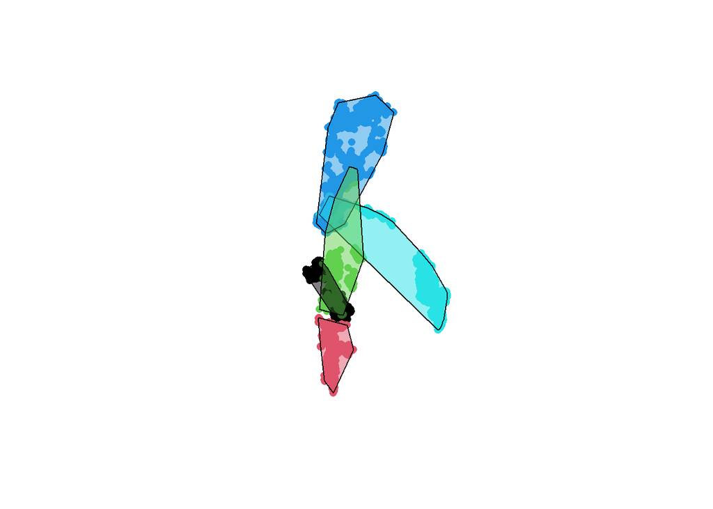

```r
### Plot
### library(scales) # Helps make polygons partly transparent using the alpha argument below
plot(feed.sp, col = as.factor(feed.sp@data$feedground), pch = 16)
plot(feed.mcp, col = alpha(1:5, 0.5), add = TRUE)
```

```r
### Calculate the MCP by including 50 to 100 percent of points
hrs_fg <- mcp.area(feed.sp, percent = seq(50, 100, by = 5))
```

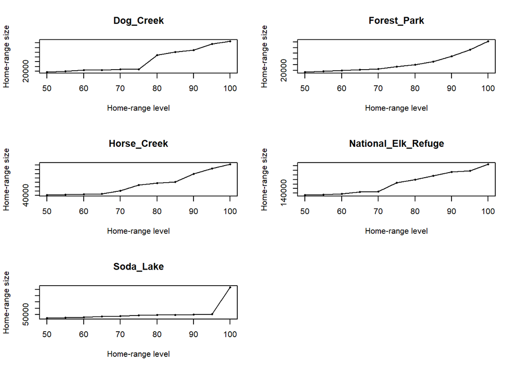

```r
hrs_fg ### examine dataframe
```

```r
### Transform the point and MCP objects.
# feed.spgeo <- spTransform(feed.sp, CRS("+proj=longlat"))
# feed.mcpgeo <- spTransform(feed.mcp, CRS("+proj=longlat"))
#
# register_stadiamaps(key = "YourAPIKey")
#
# mybasemap_fg <- get_stadiamap(bbox = c(left = min(feed.spgeo@coords[,1])-0.005,
#                                     bottom = min(feed.spgeo@coords[,2])-0.005,
#                                     right = max(feed.spgeo@coords[,1])+0.005,
#                                     top = max(feed.spgeo@coords[,2])+0.005),
#                            zoom = 12)
#
# ### Turn the spatial data frame of points into just a dataframe for plotting in ggmap
# feed.geo <- data.frame(feed.spgeo@coords,
#                           id = feed.spgeo@data$feedground )
#
# mymap.hr_fg <- ggmap(mybasemap_fg) +
#   geom_polygon(data = fortify(feed.mcpgeo),
#                ### Polygon layer needs to be "fortified" to add geometry to the dataframe
#               aes(long, lat, colour = id, fill = id),
#               alpha = 0.3) + ### alpha sets the transparency
#   geom_point(data = feed.geo,
#              aes(x = x, y = y, colour = id))  +
#   theme(legend.position = c(0.15, 0.80)) +
#   labs(x = "Longitude", y = "Latitude") +
#   scale_fill_manual(name = "Elk Feedground",
#                       values = c("red", "blue", "purple", "green", "orange"),
#                       breaks = c("Forest_Park", "National_Elk_Refuge", "Horse_Creek", "Soda_Lake", "Dog_Creek")) +
#   scale_colour_manual(name = "Elk Feedground",
#                       values = c("red", "blue", "purple", "green", "orange"),
#                       breaks = c("Forest_Park", "National_Elk_Refuge", "Horse_Creek", "Soda_Lake", "Dog_Creek"))
# mymap.hr_fg
```